# Resolução da Avaliação 3 - Valor: 34 pontos

Introdução à Ciência de Dados - 2025  
Bacharelado em Administração

Autor

Prof. Dr. Washington S. da Silva

Data de Publicação

9 de julho de 2025

## Questão 1

### Inferência sobre Proporções Populacionais

**a)** Obtenha uma estimativa pontual da proporção de clientes satisfeitos em cada grupo (($\hat{p}_A$ e $\hat{p}_B$) e da diferença entre elas ($\hat{p}_A - \hat{p}_B$).

**Solução**

```r
# Dados da pesquisa
total_satisfeitos_A <- 273
total_grupo_A <- 350

total_satisfeitos_B <- 198
total_grupo_B <- 290
```

```r
# Estimativa pontual da proporção de clientes satisfeitos do grupo A
prop_A <- total_satisfeitos_A / total_grupo_A
prop_A
```

```
[1] 0.78
```

```r
# Estimativa pontual da proporção de clientes satisfeitos do grupo B
prop_B <- total_satisfeitos_B / total_grupo_B
prop_B
```

```
[1] 0.683
```

```r
# Estimativa pontual da diferença entre as proporções
diferenca <- prop_A - prop_B
diferenca
```

```
[1] 0.0972
```

**b)** Por que em uma análise estatisticamente fundamentada, é incorreto reportar somente estimativas pontuais dos parâmetros da população?

**Resposta de Referência**

As estimativas pontuais de parâmetros da população — como a proporção de clientes satisfeitos em uma categoria de produtos — não quantificam a incerteza envolvida no uso de uma amostra para inferir algo sobre toda a população.

Por isso, é essencial apresentar um **intervalo de confiança**, que fornece um **intervalo plausível** de valores para o verdadeiro parâmetro populacional, pois incorpora o erro de amostragem e a variabilidade dos dados.

**c)** Obtenha uma estimativa por intervalo de 95% de confiança para a diferença entre as proporções ($p_A - p_B$) utilizando a função `prop.test()`.

**Solução**

```r
# Intervalo de confiança para a diferença entre proporções
prop.test(x = c(total_satisfeitos_A, total_satisfeitos_B),
          n = c(total_grupo_A, total_grupo_B),
          conf.level = 0.95
          )
```

```
    2-sample test for equality of proportions with continuity correction

data:  c(total_satisfeitos_A, total_satisfeitos_B) out of c(total_grupo_A, total_grupo_B)
X-squared = 7, df = 1, p-value = 0.007
alternative hypothesis: two.sided
95 percent confidence interval:
 0.0251 0.1693
sample estimates:
prop 1 prop 2
 0.780  0.683
```

**d)** Interprete a estimativa por intervalo obtida e indique se há evidência estatisticamente siginificativa de que uma categoria tem mais clientes satisfeitos que a outra. Justifique sua resposta.

**Resposta de Referência**

O intervalo de 95% para a diferença $p_A - p_B$ é aproximadamente:

$$[0,03, 0,17]$$

Como a estimativa do intervalo não contém zero, isso indica que a proporção de clientes satisfeitos na Categoria A é significativamente maior que na Categoria b.

Portanto, há evidência estatística significativa de que a Categoria A (produtos eletrônicos) tem uma proporção significativamente maior de clientes satisfeitos do que a Categoria B (produtos de moda). Especificamente, a diferença estimada favorável à Categoria A pode variar entre 3% e 17%, com 95% de confiança.

**e)** A diretora deseja saber se a proporção de clientes satisfeitos na Categoria A (produtos eletrônicos) é significativamente maior que 70%:

**e.1)** Formule as hipóteses nula e alternativa;

**Resposta de Referência**

$$\begin{cases}
H_0: p_A = 0,7 \\
H_A: p_A > 0,7
\end{cases}$$

**e.2)** Realize o **teste de hipótese** correspondente utilizando a função `prop.test()`, e;

**Solução**

```r
# Teste de hipótese unilateral para proporção da Categoria A
prop.test(x = total_satisfeitos_A,
          n = total_grupo_A,
          p = 0.7,
          alternative = "greater")
```

```
    1-sample proportions test with continuity correction

data:  total_satisfeitos_A out of total_grupo_A, null probability 0.7
X-squared = 10, df = 1, p-value = 0.0007
alternative hypothesis: true p is greater than 0.7
95 percent confidence interval:
 0.74 1.00
sample estimates:
   p
0.78
```

**e.3)** Interprete o resultado com base no valor-p obtido.

**Resposta de Referência**

Portanto, há **forte evidência estatística** de que a proporção de clientes satisfeitos na Categoria A é **maior que 70%**, ao nível de significância de 5%.

## Questão 2

### Inferência sobre Médias Populacionais

```r
# Cria a data.frame dados_entrega
dados_entrega <- data.frame(
  tempo = c(
    1.9908307, 3.7595980, 3.9207872, 1.9499968, 2.5570788, 2.9083451,
    3.8215787, 3.4254931, 4.1066170, 3.7159112, 2.3757705, 4.3799877,
    4.0898537, 4.6885358, 1.9032753, 4.9526208, 4.7632426, 3.5487350,
    5.2520306, 4.5840950, 2.7728566, 1.6544221, 1.9158527, 3.3874123,
    3.1677474, 4.2208561, 2.7834305, 2.9044544, 4.5360855, 2.2195599,
    2.7240852, 2.6655864, 1.4009759, 3.4665378, 3.3535627, 4.6972176,
    1.9733366, 2.5457229, 2.2336230, 2.6573906, 2.6681639, 3.1323411,
    2.4254247, 2.7917952, 4.9867621, 2.8329370, 2.8299644, 3.5470596,
    1.4070574, 3.1499424, 1.9685541, 2.4178228, 3.4466604, 3.6865291,
    3.3801921, 3.5045991, 2.2455080, 4.4135944, 3.2958687, 3.3348655,
    0.2198195, 1.6197339, 2.4793752, 3.6855232, 2.6521006, 4.5120387,
    4.4196294, 1.1254838, 2.1009464, 1.8516211, 2.5130132, 2.6551619,
    0.8074057, 4.2885169, 2.6779839
  ),
  parceiro = c(
    rep("Atual", 35),
    rep("Novo", 40)
  )
)
```

**Tarefas:**

**a)** O intervalo de confiança para a diferença de médias programado na função `t.test` assume que os dados de ambas as amostras comparadas, os dados das empresas parceiras neste caso, sigam aproximadamente uma distribuição normal, para que o intervalo estimado seja válido. Assim, verifique graficamente a normalidade das duas amostras construindo um gráfico quantil-quantil para ambas as amostras usando a função `ggqqplot()` do pacote `ggpubr`. Após gerar o gráfico, comente sobre a normalidade das duas amostras

**Solução**

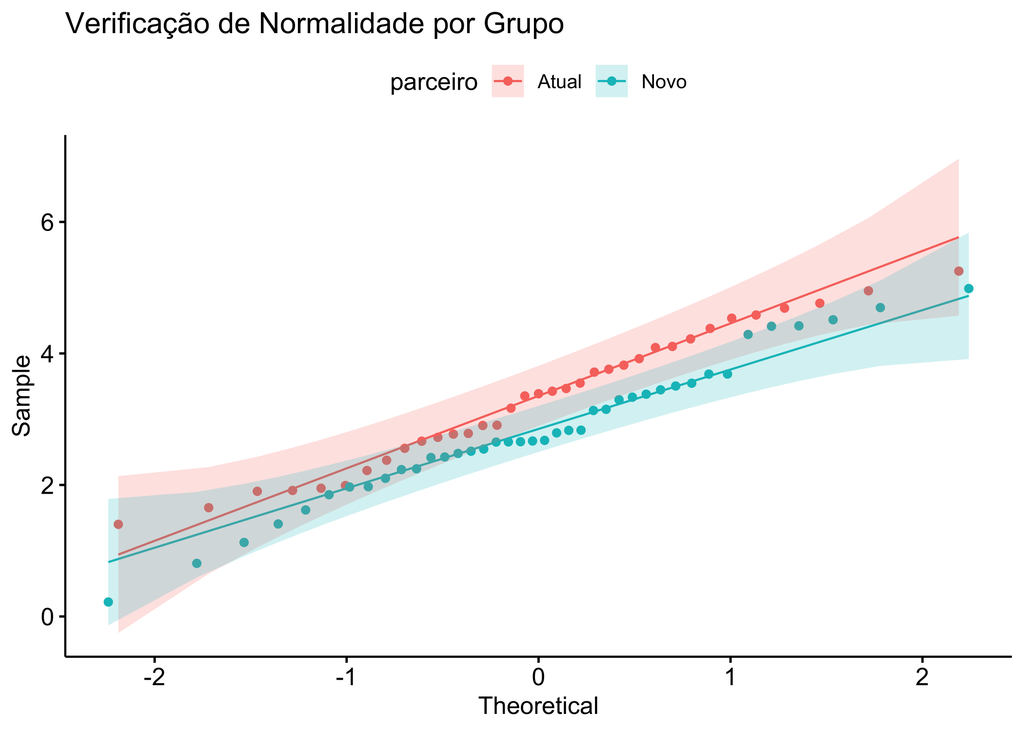

```r
# Gráfico quantile-quantile para verificar normalidade dos dados
ggqqplot(dados_entrega, x = "tempo", color = "parceiro") +
  labs(title = "Verificação de Normalidade por Grupo")
```

0 gráfico quantil-quantil (QQ) mostra que ambas as amostras seguem uma distribuição aproximadamente normal, sem grandes desvios, assim, é possível utilizar o intervalo de confiança para a diferença entre médias programado na função `t.test()`.

**b)** Obtenha uma estimativa por intervalo de 95% de confiança para a **diferença entre os tempos médios** ($\mu_A - \mu_B$) de entrega dos dois parceiros usando a função `t.test()`.

**Solução**

```r
# Estimativa por intervalo de confiança para a diferença entre médias
t.test(tempo ~ parceiro, data = dados_entrega, conf.level = 0.95)
```

```
    Welch Two Sample t-test

data:  tempo by parceiro
t = 2, df = 72, p-value = 0.05
alternative hypothesis: true difference in means between group Atual and group Novo is not equal to 0
95 percent confidence interval:
 -0.000512  0.962466
sample estimates:
mean in group Atual  mean in group Novo
               3.31                2.83
```

**c)** Observando o resultado fornecido no item anterior, quais as estimativas pontuais dos tempos médios de entrega dos dois parceiros ($\bar{x}_A$ e $\bar{x}_N$) e da diferença entre eles ($\bar{x}_A - \bar{x}_N$)? Com base apenas na estimativa pontual da diferença média entre os tempos de entrega, qual parceiro parece ter tempos médios de entrega maiores?

**Resposta de Referência**

A estimativa pontual dos tempos médios de entrega dos dois parceiros é:

- $\bar{x}_A \approx 3,31$ dias (Parceiro Atual)
- $\bar{x}_N \approx 2,83$ dias (Novo Parceiro)

A diferença pontual entre os tempos médios de entrega é: - $\bar{x}_A - \bar{x}_N \approx 0,48$ dias.

- Assim, apenas pela estimativa pontual, o Parceiro Atual parece ter um tempo médio de entrega maior que o Novo Parceiro.

**d)** Interprete a estimativa por intervalo obtida e indique se há evidência estatisticamente significativa de que um parceiro tem tempos médios de entrega maiores que o outro. Justifique sua resposta.

**Resposta de Referência**

O intervalo de 95% para a diferença $\mu_A - \mu_B$ é aproximadamente:

$$[-0.0005, 0.96]$$

Como a estimativa do intervalo **inclui zero**, isso indica que não há evidência estatística significativa de que um parceiro tem tempos médios de entrega maiores que o outro.

**Dica: Interpretação de Estimativas de Intervalos de Confiança**

- Um intervalo de confiança de 95% para uma diferença (entre médias ou proporções) representa uma faixa de valores plausíveis para a verdadeira diferença na população, com base nos dados da amostra.
- Se o zero estiver dentro do intervalo, isso fornece evidências de que há uma grande chance de que não haja diferença real entre os grupos.
- Se o zero estiver fora do intervalo, isso fornece evidências de que há uma diferença real entre os grupos.